# PM 566 Assignment 2

Author

Erica Shin

## Data Wrangling

**Question 1:**

```r
library(dplyr)
#loading in datasets
individ <- read.csv("/Users/ericashin/Documents/GitHub/PM-566-Assignments/Assignment 2/chs_individual.csv")

region <- read.csv("/Users/ericashin/Documents/GitHub/PM-566-Assignments/Assignment 2/chs_regional.csv")

#merging the two datasets
both <- merge(individ, region, by="townname")

#checking for duplicates
nrow(individ)
```

```
[1] 1200
```

```r
nrow(region)
```

```
[1] 12
```

```r
nrow(both)
```

```
[1] 1200
```

```r
unique_both <- unique(both)

## IMPUTING

#creating function to get mode
get_mode <- function(x) {
  uniq_x <- unique(x[!is.na(x)])  #removing NA values
  uniq_x[which.max(tabulate(match(x, uniq_x)))]  #finding mode
}

#imputing missing values
imputed <- both |>
  group_by(male, hispanic) |>
  mutate(across(where(is.numeric),
         ~ coalesce(., mean(., na.rm = TRUE)), .names = "{col}_imp")) |>
  mutate(across(where(is.integer) | where(is.character),
          ~ coalesce(., get_mode(.)), .names = "{col}_imp")) |>
  ungroup()

#double checking with asthma
imputed[, c("asthma", "asthma_imp")]
```

```
# A tibble: 1,200 × 2
   asthma asthma_imp
    <int>      <int>
 1      0          0
 2      0          0
 3      0          0
 4      0          0
 5      1          1
 6      0          0
 7      0          0
 8      0          0
 9     NA          0
10      0          0
# ℹ 1,190 more rows
```

**Question 2:**

```r
#creating new category called obesity_level
imputed <- imputed |>
  mutate(obesity_level = case_when(
    bmi_imp < 14 ~ "Underweight",
    bmi_imp >= 14 & bmi_imp <= 22 ~ "Normal",
    bmi_imp > 22 & bmi_imp <= 24 ~ "Overweight",
    bmi_imp > 24 ~ "Obese",
    TRUE ~ NA_character_  # Handle NA cases if needed
  ))

#creating summary table
summary_table <- imputed |>
  group_by(obesity_level) |>
  summarize(
    min_bmi = min(bmi_imp, na.rm = TRUE),
    max_bmi = max(bmi_imp, na.rm = TRUE),
    total_obs = n()
  )

summary_table
```

```
# A tibble: 4 × 4
  obesity_level min_bmi max_bmi total_obs
  <chr>           <dbl>   <dbl>     <int>
1 Normal           14.0    22.0       975
2 Obese            24.0    41.3       103
3 Overweight       22.0    24.0        87
4 Underweight      11.3    14.0        35
```

**Question 3:**

```r
#creating new categorical variable called smoke_gas_exposure
imputed <- imputed |>
  mutate(smoke_gas_exposure = case_when(
    smoke_imp == 0 & gasstove_imp == 0 ~ "No Exposure",
    smoke_imp == 1 & gasstove_imp == 0 ~ "Second Hand Smoke Only",
    smoke_imp == 0 & gasstove_imp == 1 ~ "Gas Stove Only",
    smoke_imp == 1 & gasstove_imp == 1 ~ "Both Exposures",
    TRUE ~ NA_character_  #handling NA cases if needed
  ))

#making table to check distribution
table(imputed$smoke_gas_exposure)
```

```
        Both Exposures         Gas Stove Only            No Exposure
                   154                    791                    219
Second Hand Smoke Only
                    36
```

**Question 4:**

```r
#summary table by town
summary_town <- imputed |>
  group_by(townname_imp) |>
  summarize(
    mean_fev = mean(fev_imp, na.rm = TRUE),
    sd_fev = sd(fev_imp, na.rm = TRUE),
    total_obs = n()
  )

#summary table by sex
summary_sex <- imputed |>
  group_by(male) |>
  summarize(
    mean_fev = mean(fev_imp, na.rm = TRUE),
    sd_fev = sd(fev_imp, na.rm = TRUE),
    total_obs = n()
  )

#summary table by obesity level
summary_obesity <- imputed |>
  group_by(obesity_level) |>
  summarize(
    mean_fev = mean(fev_imp, na.rm = TRUE),
    sd_fev = sd(fev_imp, na.rm = TRUE),
    total_obs = n()
  )

#summary table by smoke gas exposure
summary_smoke_gas <- imputed |>
  group_by(smoke_gas_exposure) |>
  summarize(
    mean_fev = mean(fev_imp, na.rm = TRUE),
    sd_fev = sd(fev_imp, na.rm = TRUE),
    total_obs = n()
  )

summary_town
```

```
# A tibble: 12 × 4
   townname_imp  mean_fev sd_fev total_obs
   <chr>            <dbl>  <dbl>     <int>
 1 Alpine           2087.   291.       100
 2 Atascadero       2076.   324.       100
 3 Lake Elsinore    2039.   304.       100
 4 Lake Gregory     2085.   320.       100
 5 Lancaster        2003.   317.       100
 6 Lompoc           2034.   351.       100
 7 Long Beach       1986.   319.       100
 8 Mira Loma        1985.   325.       100
 9 Riverside        1990.   278.       100
10 San Dimas        2027.   319.       100
11 Santa Maria      2026.   312.       100
12 Upland           2024.   343.       100
```

```r
summary_sex
```

```
# A tibble: 2 × 4
   male mean_fev sd_fev total_obs
  <int>    <dbl>  <dbl>     <int>
1     0    1959.   312.       610
2     1    2104.   308.       590
```

```r
summary_obesity
```

```
# A tibble: 4 × 4
  obesity_level mean_fev sd_fev total_obs
  <chr>            <dbl>  <dbl>     <int>
1 Normal           2000.   295.       975
2 Obese            2266.   325.       103
3 Overweight       2224.   317.        87
4 Underweight      1698.   303.        35
```

```r
summary_smoke_gas
```

```
# A tibble: 4 × 4
  smoke_gas_exposure     mean_fev sd_fev total_obs
  <chr>                     <dbl>  <dbl>     <int>
1 Both Exposures            2025.   301.       154
2 Gas Stove Only            2023.   319.       791
3 No Exposure               2057.   329.       219
4 Second Hand Smoke Only    2056.   296.        36
```

## Looking at the Data (EDA)

**Following EDA checklist for overall dataset**

```r
## EDA checklist for overall dataset "imputed"

#reading in the data
imputed
```

```
# A tibble: 1,200 × 98
   townname   sid  male race  hispanic agepft height weight   bmi asthma
   <chr>    <int> <int> <chr>    <int>  <dbl>  <int>  <int> <dbl>  <int>
 1 Alpine     841     1 W            1  10.5     150     78  15.8      0
 2 Alpine     835     0 W            0  10.1     143     69  15.3      0
 3 Alpine     838     0 O            1   9.49    133     62  15.9      0
 4 Alpine     840     0 W            0   9.97    146     78  16.6      0
 5 Alpine     865     0 W            0  10.0     162    140  24.2      1
 6 Alpine     867     0 W            1   9.96    141     94  21.5      0
 7 Alpine     842     1 M            1   9.49    139     65  15.3      0
 8 Alpine     839     0 M            1  10.1     142     86  19.4      0
 9 Alpine     844     1 W            1  10.5     143     65  14.4     NA
10 Alpine     847     1 M            0   9.90    137     69  16.7      0
# ℹ 1,190 more rows
# ℹ 88 more variables: active_asthma <int>, father_asthma <int>,
#   mother_asthma <int>, wheeze <int>, hayfever <int>, allergy <int>,
#   educ_parent <int>, smoke <int>, pets <int>, gasstove <int>, fev <dbl>,
#   fvc <dbl>, mmef <dbl>, pm25_mass <dbl>, pm25_so4 <dbl>, pm25_no3 <dbl>,
#   pm25_nh4 <dbl>, pm25_oc <dbl>, pm25_ec <dbl>, pm25_om <dbl>, pm10_oc <dbl>,
#   pm10_ec <dbl>, pm10_tc <dbl>, formic <dbl>, acetic <dbl>, hcl <dbl>, …
```

```r
#checking size of data
dim(imputed)
```

```
[1] 1200   98
```

```r
#examining the variables and their types

str(imputed)
```

```
tibble [1,200 × 98] (S3: tbl_df/tbl/data.frame)
 $ townname          : chr [1:1200] "Alpine" "Alpine" "Alpine" "Alpine" ...
 $ sid               : int [1:1200] 841 835 838 840 865 867 842 839 844 847 ...
 $ male              : int [1:1200] 1 0 0 0 0 0 1 0 1 1 ...
 $ race              : chr [1:1200] "W" "W" "O" "W" ...
 $ hispanic          : int [1:1200] 1 0 1 0 0 1 1 1 1 0 ...
 $ agepft            : num [1:1200] 10.55 10.1 9.49 9.97 10.04 ...
 $ height            : int [1:1200] 150 143 133 146 162 141 139 142 143 137 ...
 $ weight            : int [1:1200] 78 69 62 78 140 94 65 86 65 69 ...
 $ bmi               : num [1:1200] 15.8 15.3 15.9 16.6 24.2 ...
 $ asthma            : int [1:1200] 0 0 0 0 1 0 0 0 NA 0 ...
 $ active_asthma     : int [1:1200] 0 0 0 0 1 0 0 0 0 0 ...
 $ father_asthma     : int [1:1200] 0 0 0 0 0 NA 0 0 NA 0 ...
 $ mother_asthma     : int [1:1200] 0 0 0 0 0 0 0 1 NA 0 ...
 $ wheeze            : int [1:1200] 0 0 0 0 1 0 1 1 NA 0 ...
```

[output cut: 84 more lines]

```r
summary(imputed)
```

```
   townname              sid              male            race
 Length:1200        Min.   :   1.0   Min.   :0.0000   Length:1200
 Class :character   1st Qu.: 528.8   1st Qu.:0.0000   Class :character
 Mode  :character   Median :1041.5   Median :0.0000   Mode  :character
                    Mean   :1037.5   Mean   :0.4917
                    3rd Qu.:1554.2   3rd Qu.:1.0000
                    Max.   :2053.0   Max.   :1.0000

    hispanic          agepft           height        weight
 Min.   :0.0000   Min.   : 8.961   Min.   :114   Min.   : 42.00
 1st Qu.:0.0000   1st Qu.: 9.610   1st Qu.:135   1st Qu.: 65.00
 Median :0.0000   Median : 9.906   Median :139   Median : 74.00
 Mean   :0.4342   Mean   : 9.924   Mean   :139   Mean   : 79.33
 3rd Qu.:1.0000   3rd Qu.:10.177   3rd Qu.:143   3rd Qu.: 89.00
 Max.   :1.0000   Max.   :12.731   Max.   :165   Max.   :207.00
                  NA's   :89       NA's   :89    NA's   :89
      bmi            asthma       active_asthma  father_asthma
 Min.   :11.30   Min.   :0.0000   Min.   :0.00   Min.   :0.00000
 1st Qu.:15.78   1st Qu.:0.0000   1st Qu.:0.00   1st Qu.:0.00000
 Median :17.48   Median :0.0000   Median :0.00   Median :0.00000
 Mean   :18.50   Mean   :0.1463   Mean   :0.19   Mean   :0.08318
 3rd Qu.:20.35   3rd Qu.:0.0000   3rd Qu.:0.00   3rd Qu.:0.00000
 Max.   :41.27   Max.   :1.0000   Max.   :1.00   Max.   :1.00000
 NA's   :89      NA's   :31                      NA's   :106
 mother_asthma        wheeze          hayfever         allergy
 Min.   :0.0000   Min.   :0.0000   Min.   :0.0000   Min.   :0.0000
 1st Qu.:0.0000   1st Qu.:0.0000   1st Qu.:0.0000   1st Qu.:0.0000
 Median :0.0000   Median :0.0000   Median :0.0000   Median :0.0000
 Mean   :0.1023   Mean   :0.3313   Mean   :0.1747   Mean   :0.2929
 3rd Qu.:0.0000   3rd Qu.:1.0000   3rd Qu.:0.0000   3rd Qu.:1.0000
 Max.   :1.0000   Max.   :1.0000   Max.   :1.0000   Max.   :1.0000
 NA's   :56       NA's   :71       NA's   :118      NA's   :63
  educ_parent        smoke             pets           gasstove
 Min.   :1.000   Min.   :0.0000   Min.   :0.0000   Min.   :0.0000
 1st Qu.:2.000   1st Qu.:0.0000   1st Qu.:1.0000   1st Qu.:1.0000
 Median :3.000   Median :0.0000   Median :1.0000   Median :1.0000
 Mean   :2.797   Mean   :0.1638   Mean   :0.7667   Mean   :0.7815
 3rd Qu.:3.000   3rd Qu.:0.0000   3rd Qu.:1.0000   3rd Qu.:1.0000
 Max.   :5.000   Max.   :1.0000   Max.   :1.0000   Max.   :1.0000
 NA's   :64      NA's   :40                        NA's   :33
```

[output cut: 141 more lines]

```
 3rd Qu.:25.93   3rd Qu.:3.817   3rd Qu.:5.982   3rd Qu.: 9.395
 Max.   :31.55   Max.   :4.620   Max.   :7.400   Max.   :11.430

    lon_imp          lat_imp      townname_imp         race_imp
 Min.   :-120.7   Min.   :32.84   Length:1200        Length:1200
 1st Qu.:-118.8   1st Qu.:33.93   Class :character   Class :character
 Median :-117.7   Median :34.10   Mode  :character   Mode  :character
 Mean   :-118.3   Mean   :34.20
 3rd Qu.:-117.4   3rd Qu.:34.65
 Max.   :-116.8   Max.   :35.49

 obesity_level      smoke_gas_exposure
 Length:1200        Length:1200
 Class :character   Class :character
 Mode  :character   Mode  :character
```

```r
#looking at the top and bottom of the data
head(imputed)
```

```
# A tibble: 6 × 98
  townname   sid  male race  hispanic agepft height weight   bmi asthma
  <chr>    <int> <int> <chr>    <int>  <dbl>  <int>  <int> <dbl>  <int>
1 Alpine     841     1 W            1  10.5     150     78  15.8      0
2 Alpine     835     0 W            0  10.1     143     69  15.3      0
3 Alpine     838     0 O            1   9.49    133     62  15.9      0
4 Alpine     840     0 W            0   9.97    146     78  16.6      0
5 Alpine     865     0 W            0  10.0     162    140  24.2      1
6 Alpine     867     0 W            1   9.96    141     94  21.5      0
# ℹ 88 more variables: active_asthma <int>, father_asthma <int>,
#   mother_asthma <int>, wheeze <int>, hayfever <int>, allergy <int>,
#   educ_parent <int>, smoke <int>, pets <int>, gasstove <int>, fev <dbl>,
#   fvc <dbl>, mmef <dbl>, pm25_mass <dbl>, pm25_so4 <dbl>, pm25_no3 <dbl>,
#   pm25_nh4 <dbl>, pm25_oc <dbl>, pm25_ec <dbl>, pm25_om <dbl>, pm10_oc <dbl>,
#   pm10_ec <dbl>, pm10_tc <dbl>, formic <dbl>, acetic <dbl>, hcl <dbl>,
#   hno3 <dbl>, o3_max <dbl>, o3106 <dbl>, o3_24 <dbl>, no2 <dbl>, …
```

```r
tail(imputed)
```

```
# A tibble: 6 × 98
  townname   sid  male race  hispanic agepft height weight   bmi asthma
  <chr>    <int> <int> <chr>    <int>  <dbl>  <int>  <int> <dbl>  <int>
1 Upland    1866     0 O            1   9.81    139     60  14.1      0
2 Upland    1867     0 M            1   9.62    140     71  16.5      0
3 Upland    2033     0 M            0  10.1     130     67  18.0      0
4 Upland    2031     1 W            0   9.80    135     83  20.7      0
5 Upland    2032     1 W            0   9.55    137     59  14.3      0
6 Upland    2053     0 W            0  NA        NA     NA  NA        0
# ℹ 88 more variables: active_asthma <int>, father_asthma <int>,
#   mother_asthma <int>, wheeze <int>, hayfever <int>, allergy <int>,
#   educ_parent <int>, smoke <int>, pets <int>, gasstove <int>, fev <dbl>,
#   fvc <dbl>, mmef <dbl>, pm25_mass <dbl>, pm25_so4 <dbl>, pm25_no3 <dbl>,
#   pm25_nh4 <dbl>, pm25_oc <dbl>, pm25_ec <dbl>, pm25_om <dbl>, pm10_oc <dbl>,
#   pm10_ec <dbl>, pm10_tc <dbl>, formic <dbl>, acetic <dbl>, hcl <dbl>,
#   hno3 <dbl>, o3_max <dbl>, o3106 <dbl>, o3_24 <dbl>, no2 <dbl>, …
```

```r
#looking at key variables of interest (BMI, FEV, smoke/gas exposure, PM 2.5 mass)
summary(imputed$bmi_imp)
```

```
   Min. 1st Qu.  Median    Mean 3rd Qu.    Max.
  11.30   15.96   17.81   18.50   19.99   41.27
```

```r
summary(imputed$fev_imp)
```

```
   Min. 1st Qu.  Median    Mean 3rd Qu.    Max.
  984.8  1827.6  2016.4  2030.1  2223.6  3323.7
```

```r
table(imputed$smoke_gas_exposure)
```

```
        Both Exposures         Gas Stove Only            No Exposure
                   154                    791                    219
Second Hand Smoke Only
                    36
```

```r
summary(imputed$pm25_mass_imp)
```

```
   Min. 1st Qu.  Median    Mean 3rd Qu.    Max.
  5.960   7.615  10.545  14.362  20.988  29.970
```

The dimensions of the combined, imputed dataset are 1200 rows/observations by 98 columns. I decided to keep the original variables without the imputed information and made new variables for the imputed information so that I could compare the two values to make sure the imputing worked. The variables in the dataset are made up on numeric, integer, and character types. Looking at the key variables (BMI, FEV, smoke/gas exposure, PM 2.5 mass) for the three primary questions of interest, there does not appear to be any abnormalities in the data.

**Primary Questions of Interest (to consider):**

1) What is the association between BMI and FEV (forced expiratory volume)?

2) What is the association between smoke/gas exposure and FEV?

3) What is the association between PM2.5 exposure and FEV?

## Visualization

**Question 1:** Facet plot showing scatterplots with regression lines of BMI vs FEV by “townname”.

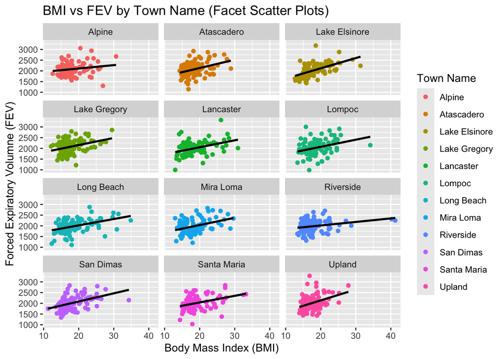

```r
library(ggplot2)

imputed |>
  filter(!is.na(townname_imp)) |>
  ggplot(mapping=aes(x=bmi_imp, y=fev_imp, color=townname_imp)) +
  geom_point() +
  facet_wrap(~ townname_imp, nrow=4) +
  geom_smooth(method = "lm", se = FALSE, col="black") +
  labs(title = "BMI vs FEV by Town Name (Facet Scatter Plots)",
       x = "Body Mass Index (BMI)",
       y = "Forced Expiratory Volumne (FEV)",
       color = "Town Name")
```

Interpretation:

The facet plot demonstrates that each plot of the 12 towns has a positive regression line of BMI of FEV. This means that there is a positive relationship between BMI and FEV for all 12 towns. In other words, higher BMI is associated with higher FEV in each of the 12 towns. It appears that Upland has the steepest (positive) regression line, which could indicate a stronger relationship between BMI and FEV for this specific town compared to other towns. On the other hand, Alpine seems to have the flattest (positive) regression line, which could suggest a weaker relationship between BMI and FEV compared to the other towns.

**Question 2:** Stacked histograms of FEV by BMI category and FEV by smoke/gas exposure. Use different color schemes than the ggplot default.

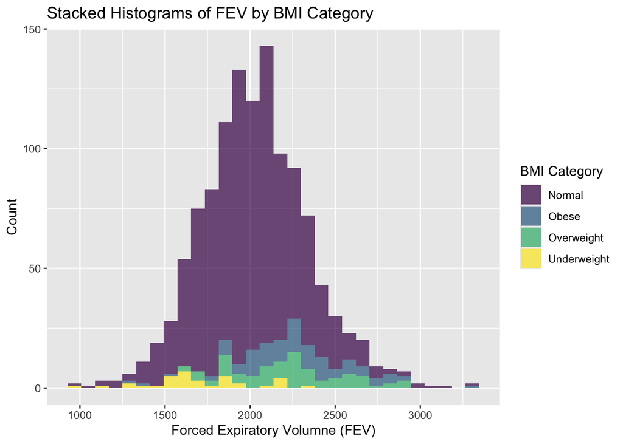

```r
#stacked histogram of FEV by BMI Category (obesity_level)
imputed |>
  filter(!is.na(fev_imp) & !is.na(obesity_level)) |>
ggplot(mapping=aes(x = fev_imp, fill = obesity_level)) +
  geom_histogram(position = "stack", bins = 30, alpha = 0.7) +
  labs(title = "Stacked Histograms of FEV by BMI Category",
       x = "Forced Expiratory Volumne (FEV)",
       y = "Count",
       fill = "BMI Category") +
  scale_fill_viridis_d()
```

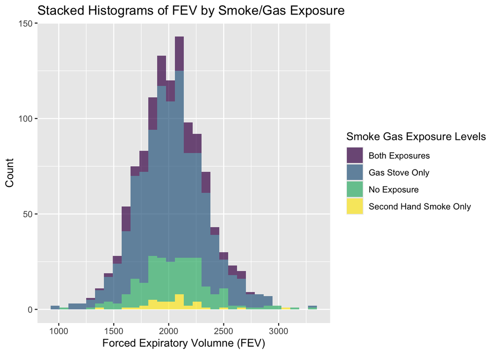

```r
#stacked histogram of FEV by smoke/gas exposure
imputed |>
  filter(!is.na(fev_imp) & !is.na(smoke_gas_exposure)) |>
  ggplot(mapping=aes(x = fev_imp, fill = smoke_gas_exposure)) +
  geom_histogram(position = "stack", bins = 30, alpha = 0.7) +
  labs(title = "Stacked Histograms of FEV by Smoke/Gas Exposure",
       x = "Forced Expiratory Volumne (FEV)",
       y = "Count",
       fill = "Smoke Gas Exposure Levels") +
  scale_fill_viridis_d()
```

**Question 3:** Barchart of BMI by smoke/gas exposure.

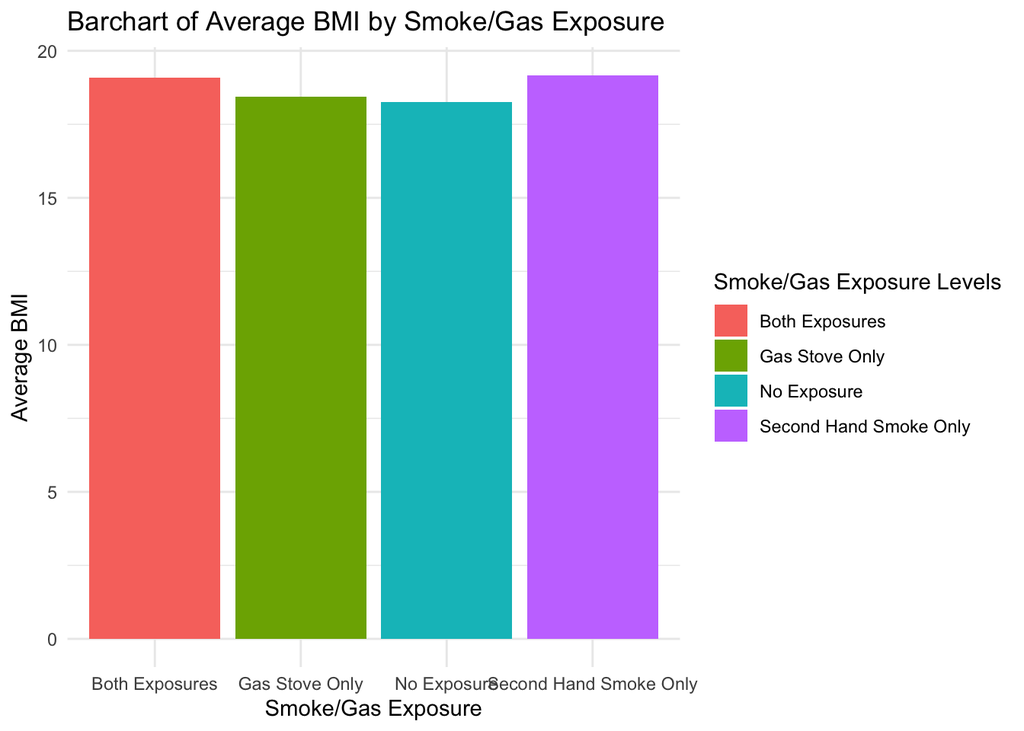

```r
#barchart showing average BMI by smoke/gas exposure category
library(data.table)
imputed1 <- as.data.table(imputed)

imputed_avg <- imputed1[, .(
  bmi_avg = mean(bmi_imp, na.rm = TRUE)),
  by = smoke_gas_exposure]

imputed_avg |>
  filter(!is.na(bmi_avg) & !is.na(smoke_gas_exposure)) |>
  ggplot(mapping=aes(x = smoke_gas_exposure, y = bmi_avg, fill = smoke_gas_exposure)) +
  geom_bar(stat = "identity") +
  labs(title = "Barchart of Average BMI by Smoke/Gas Exposure",
       x = "Smoke/Gas Exposure",
       y = "Average BMI",
       fill = "Smoke/Gas Exposure Levels") +
  theme_minimal()
```

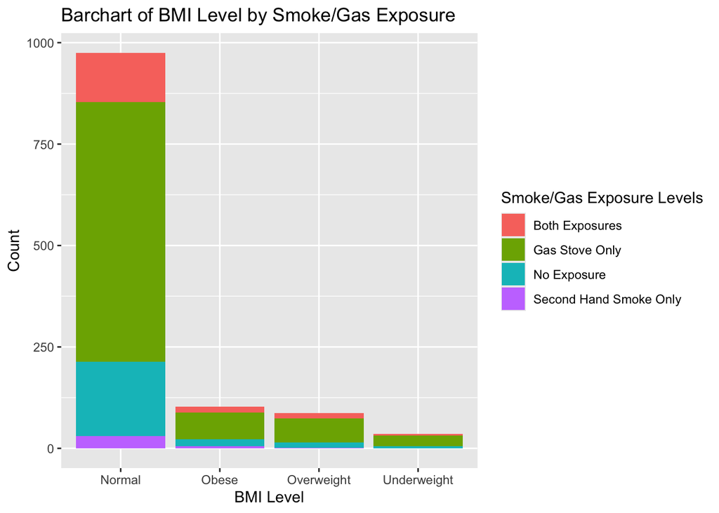

```r
#using BMI/obesity level instead of raw BMI (supplementary support for interpretation)
imputed |>
  filter(!is.na(obesity_level) & !is.na(smoke_gas_exposure)) |>
  ggplot() +
  geom_bar(mapping=aes(x=obesity_level, fill=smoke_gas_exposure)) +
  labs(title = "Barchart of BMI Level by Smoke/Gas Exposure",
       x = "BMI Level",
       y = "Count",
       fill = "Smoke/Gas Exposure Levels")
```

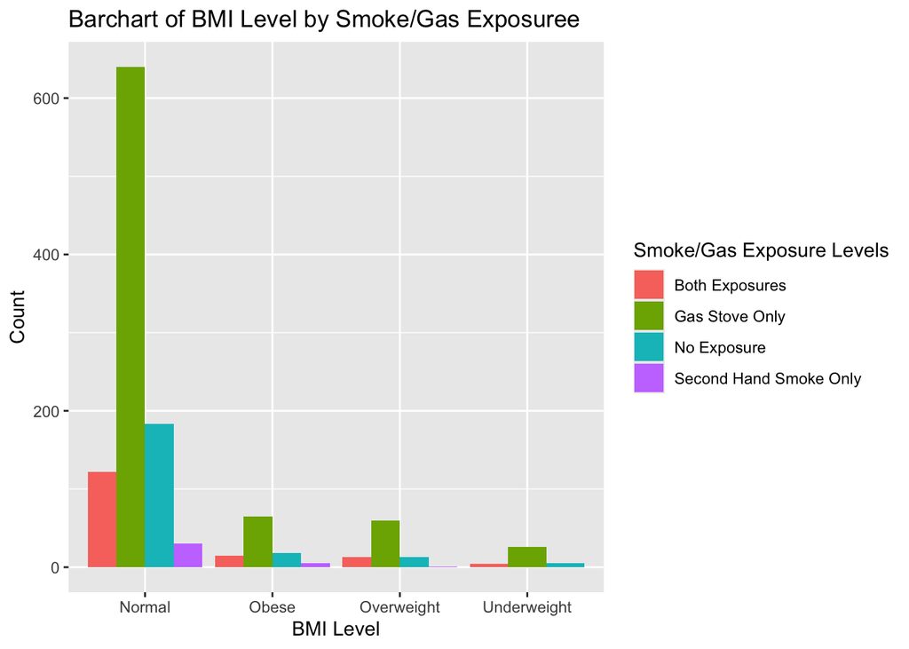

```r
#another visualization using BMI/obesity level instead of raw BMI (supplementary support for interpretation)
imputed |>
  filter(!is.na(obesity_level) & !is.na(smoke_gas_exposure)) |>
  ggplot(mapping=aes(x = obesity_level, fill = smoke_gas_exposure)) +
  geom_bar(position = "dodge") +
  labs(title = "Barchart of BMI Level by Smoke/Gas Exposuree",
       x = "BMI Level",
       y = "Count",
       fill = "Smoke/Gas Exposure Levels")
```

Interpretation:

The two barcharts of BMI level by smoke/gas exposure demonstrate that the majority of observations (~1000) fall within the “Normal” BMI category. Within the “Normal” BMI category, most of the observations fall within the “Gas Stove Only” exposure level. The “Underweight” category has the least amount of observations. “Obese” and “Overweight” seem to have a similar number of observations. Across the four categories, the “Gas Stove Only” seems to be the most prevalent smoke/gas exposure level.

**Question 4:** Statistical summary graph of FEV by BMI and FEV by smoke/gas exposure category.

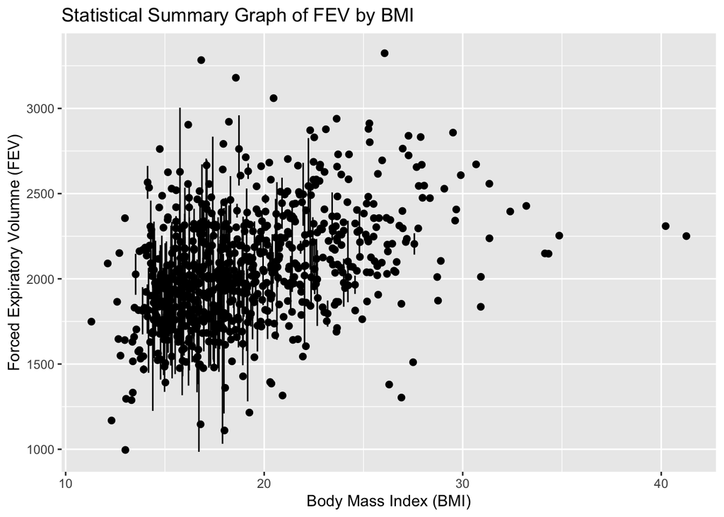

```r
#statistical summary graph of FEV by (raw) BMI
imputed |>
  filter(!is.na(fev_imp) & !is.na(bmi_imp)) |>
  ggplot() +
  stat_summary(mapping=aes(x=bmi_imp, y=fev_imp),
               fun.min = min,
               fun.max = max,
               fun = mean,
               size = 0.3) +
  labs(title = "Statistical Summary Graph of FEV by BMI",
       x = "Body Mass Index (BMI)",
       y = "Forced Expiratory Volumne (FEV)")
```

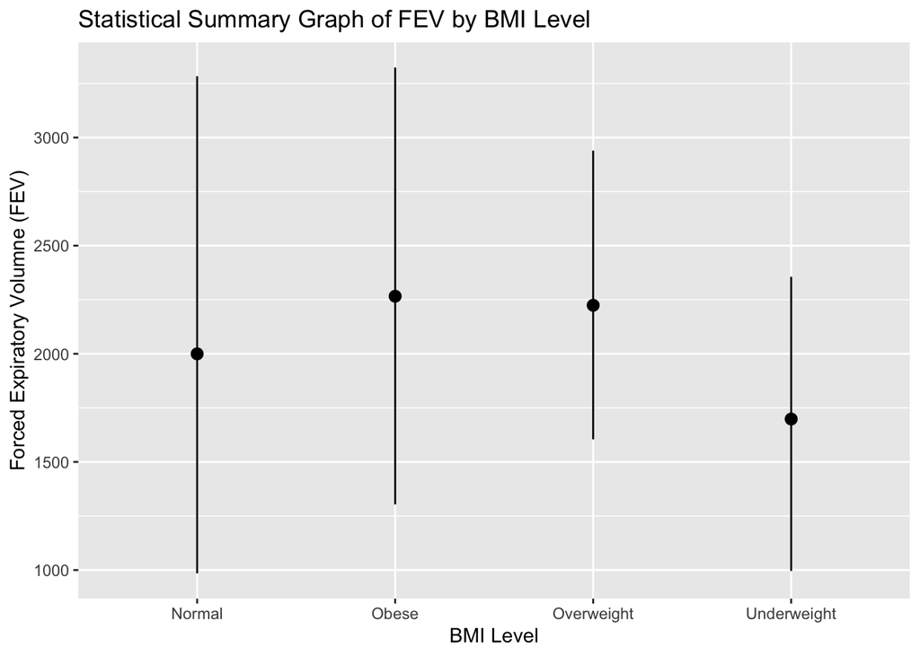

```r
#statistical summary graph of FEV by BMI Level (supplementary support for interpretation)
imputed |>
  filter(!is.na(fev_imp) & !is.na(obesity_level)) |>
  ggplot() +
  stat_summary(mapping=aes(x=obesity_level, y=fev_imp),
               fun.min = min,
               fun.max = max,
               fun = mean) +
  labs(title = "Statistical Summary Graph of FEV by BMI Level",
       x = "BMI Level",
       y = "Forced Expiratory Volumne (FEV)")
```

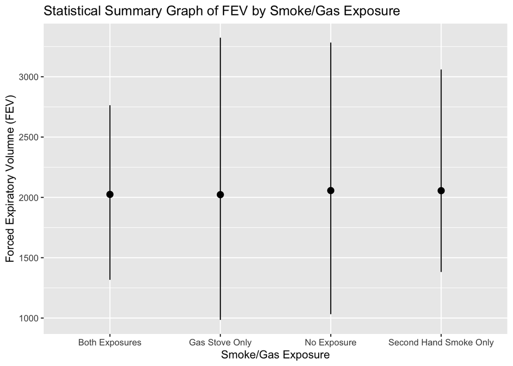

```r
#statistical summary graph of FEV by smoke/gas exposure category
imputed |>
  filter(!is.na(fev_imp) & !is.na(smoke_gas_exposure)) |>
  ggplot() +
  stat_summary(mapping=aes(x=smoke_gas_exposure, y=fev_imp),
               fun.min = min,
               fun.max = max,
               fun = mean) +
  labs(title = "Statistical Summary Graph of FEV by Smoke/Gas Exposure",
       x = "Smoke/Gas Exposure",
       y = "Forced Expiratory Volumne (FEV)")
```

Interpretation:

The statistical summary graph of FEV by (raw) BMI demonstrates a positive association between the two variables with the points following a positive, upward trend. The variability in reference lines indicates variability in mean, minimum, and maximum values.

The statistical summary graph of FEV by smoke/gas exposure indicates that the mean values for all four smoke/gas exposure levels are relatively close to each other (mean value for all categories is around 2000). The “Both Exposures” category has the smallest range of FEV (~1400, 2750) while the “Gas Stove Only” category has the widest range of FEV (~1000, 3300).

**Question 5:** A leaflet map showing the concentrations of PM2.5 mass in each of the CHS communities.

```r
#loading in leaflet library
library(leaflet)

#creating color palette for pm 2.5 mass
pm25.pal <- colorNumeric(c('gold','orange','red'), domain=imputed$pm25_mass)

#mapping with leaflet
leaflet() |>
  addProviderTiles('CartoDB.Positron') |>
  addCircles(data=imputed, lat=~lat_imp, lng=~lon_imp, popup = ~paste(townname_imp, "<br>", "PM2.5 Concentration: ", pm25_mass, "µg/m³"), opacity=1, fillOpacity=1, radius=~pm25_mass*300, color=~pm25.pal(pm25_mass)) |>
  addLegend('bottomleft', pal=pm25.pal, values=imputed$pm25_mass,
          title='PM 2.5 Mass (µg/m³) in CHS Communities', opacity=1)
```

[interactive chart not shown]

Interpretation:

The leaflet map shows that PM 2.5 mass is most highly concentrated in Mira Loma (29.97 µg/m³) among the CHS communities. Upland and Riverside also contain high concentrations of PM 2.5 mass at 22.46 µg/m³ and 22.39 µg/m³, respectively. Lompoc has the lowest concentration of PM 2.5 mass at 5.96 µg/m³. Overall, the map indicates that higher concentrations of PM 2.5 mass are located around Los Angeles while lower concentrations are found more north or south of Los Angeles (e.g., closer to central California or San Diego).

**Question 6:** Choose a visualization to examine whether PM2.5 mass is associated with FEV.

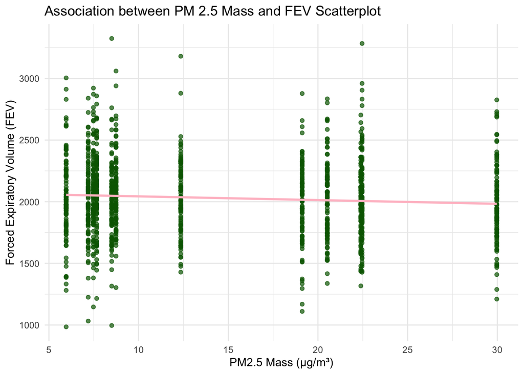

```r
#scatterplot with linear regression line
imputed |>
  filter(!is.na("pm25_mass_imp") & !is.na("fev_imp")) |>
ggplot(mapping=aes(x = pm25_mass_imp, y = fev_imp)) +
  geom_point(alpha = 0.7, color = "darkgreen") +
  geom_smooth(method = "lm", color = "pink", se = FALSE) +
  labs(title = "Association between PM 2.5 Mass and FEV Scatterplot",
       x = "PM2.5 Mass (µg/m³)",
       y = "Forced Expiratory Volume (FEV)") +
  theme_minimal()
```

```r
#running regression
summary(lm(fev_imp ~ pm25_mass_imp, data = imputed))
```

```
Call:
lm(formula = fev_imp ~ pm25_mass_imp, data = imputed)

Residuals:
     Min       1Q   Median       3Q      Max
-1070.63  -206.57   -13.33   195.87  1277.65

Coefficients:
              Estimate Std. Error t value Pr(>|t|)
(Intercept)   2073.452     19.309 107.383   <2e-16 ***
pm25_mass_imp   -3.016      1.184  -2.548    0.011 *
---
Signif. codes:  0 '***' 0.001 '**' 0.01 '*' 0.05 '.' 0.1 ' ' 1

Residual standard error: 317.3 on 1198 degrees of freedom
Multiple R-squared:  0.005389,  Adjusted R-squared:  0.004559
F-statistic: 6.492 on 1 and 1198 DF,  p-value: 0.01096
```

Interpretation:

In the scatter plot of PM 2.5 mass and FEV, the regression line (pink) slopes slightly downward. This suggests an inverse relationship between the two variables. In other words, higher PM 2.5 mass is associated with lower FEV. However, the slope is only slightly negative so the inverse relationship between PM 2.5 mass and FEV does not appear to be very strong.

Based on the regression results, PM 2.5 mass is significantly associated with FEV. The coefficient of -3.016 suggests that for each unit increase in PM 2.5 mass, FEV decreases by 3.016 units. This demonstrates a negative relationship. The p-value for PM 2.5 mass is 0.011, which is less than the common significance level of 0.05. This means we reject the null hypothesis, indicating that the relationship between PM2.5 mass and FEV is statistically significant. The F-statistic (6.492) and its associated p-value (0.01096) indicate that the model as a whole is significant, suggesting that at least one predictor (in this case, PM 2.5 mass) has a significant association with FEV.

While the results demonstrate a significant association, the low R-squared value (0.005389) indicates that PM 2.5 mass explains only a small portion of the variability in FEV. This suggests that other factors may also play important roles in influencing FEV.